# Models with Nonlinear Response

Steve Elston

03/28/2021

# Introduction

- Building models with nonlinear or non-Normal response
- Use generalized linear model for nonlinear response
- Link function transforms to nonlinear model to linear model
- Evaluating Binomial response models
- Compare model performance with deviance

# Models with Nonlinear Response

How do we deal with models that do not have nonlinear response variables?

- Example: binary response variable, $[0,1]$, $Bin(\theta)$ distributed
  - Probability parameter $\theta$
  - A binary classifier
- Example: Intensity of an arrival process, $poisson(\lambda)$ response
  - $\lambda$ is the averate rate or **intensity** of a point process
  - Estimate the parameter $\lambda$
- Example: Categorical response variable for $n$ categories, $Multi(\pi_1, \pi_2, \ldots, \pi_n)$:
  - $n$ category classifier
  - Response is probability probability for each category, $\Pi = [\pi_1, \pi_2, \ldots, \pi_n]$

# Models with Nonlinear Response

The **generalized linear model (GLM)** is a framework for nonlinear response models

- Nonlinear response is non-Normally distributed
- For each distribution use a **link function** to transform to a linear model
  - Linear model has Normally distributed response
  - Link function transform nonlinear response to Normal distribution
- To compute the nonlinear response
  - Start with a linear model, OLS
  - Transform response with **inverse link function**
  - Works for all exponential family response distributions

# The Generalized Linear Model

Link functions are avaialble for many distributions

- Supported in [statsmodels](https://www.statsmodels.org/stable/glm.html)
- Supported in [Scikit-Learn](https://scikit-learn.org/stable/modules/linear_model.html#generalized-linear-regression)
- Examples:
  - Gaussian, identity function
  - Inverse Gaussian
  - Binomial, logit function
  - Multinomial
  - Poisson
  - Negative Binomial
  - Gamma
  - Tweedie

# The Generalized Linear Model

Start with a regression model for binary classification - **logistic regression**

- Use Binomial distribution to model $y$ successes in $n$ trials

$$y \sim Bi(n, \theta)$$

- But finding best fit value of parameter $\theta$ directly is a nonlinear problem!
- Instead, define a **link function**, known as the **logit function** for parameter $\lambda$

$$\lambda = log \Bigg\{ \frac{\theta}{1-\theta} \Bigg\}$$

- After a bit of algebra we find the exponential relationship with $y$

$$y = n\ log(1+ e^\lambda)$$

# The Generalized Linear Model

Formulate a linear regression problem using the link function

$$\lambda = log \Bigg\{ \frac{\theta}{1-\theta} \Bigg\} = X \vec{b}$$
for model matrix $X$ and coefficient vector $\vec{b}$

- Given estimate of $\lambda$, compute $\theta$

$$\theta = \frac{1}{1 + e^\lambda} = \frac{1}{1 + e^{X \vec{b}}}$$

The **inverse link function** for Binomial response!

# The Generalized Linear Model

Consider the example for a single feature, $x$

- The linear model has only slope and intercept, $[ \beta_0, \beta_1]$

$$\lambda_i = log \Bigg\{ \frac{\theta_i}{1-\theta_i} \Bigg\} = \beta_0 + \beta_1 x_i$$

and

$$\theta_i = \frac{1}{1 + e^{\beta_0 + \beta_1 x_i}}$$

# Logisitc Regaresion Model

What does the transformation function look like?

$$y = \frac{1}{1 + e^\lambda}$$

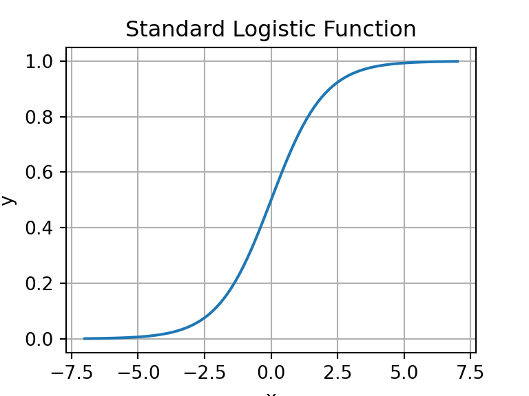

- The response is bound in the range $[0,1]$
- We say the logistic transformation **squashes** the linear response $\lambda =X \vec{b}$ to binary, $[0,1]$
- Can set a **decision threshold** for binary response
  - Default $= 0.5$

# Evaluation of Classifiers

How can we evaluate a classifier’s accuracy?

- Determine proportions of test cases which are classified as:
  - True Positives (TP): Are positive and should be positive
  - True Negatives (TN): Are negative and should be negative
  - False Positives (FP): Classified as positive but are actually negative; **Type I errors**
  - False Negatives (FN): Classified as negative but are actually positive; **Type II errors**
- Organize these metrics into a **confusion matrix**

|  | Classified Positive | Classified Negative |
| --- | --- | --- |
| Positive | TP | FN |
| Negative | FP | TN |

# Evaluation of Classifiers

# Example of Logisitic Regression

How well can we predict the type of school given the test scores?

```python
## Prep the data
test_scores['schtyp'] = np.subtract(test_scores['schtyp'], 1)
for col in ['read', 'write', 'math', 'science', 'socst']:
    test_scores[col] = np.divide(np.subtract(test_scores[col], np.mean(test_scores[col])), np.std(test_scores[col]))

## Fit the model
formula = 'schtyp ~ math'
logistic_reg_model = smf.glm(formula=formula, data=test_scores, family=sm.families.Binomial()).fit()

## score the results
threshold=0.18
test_scores['predicted'] = logistic_reg_model.predict()
test_scores['score'] = [1 if x>threshold else 0 for x in test_scores['predicted']]

print(logistic_reg_model.summary())
```

```
##                  Generalized Linear Model Regression Results
## ==============================================================================
## Dep. Variable:                 schtyp   No. Observations:                  200
## Model:                            GLM   Df Residuals:                      198
## Model Family:                Binomial   Df Model:                            1
## Link Function:                  logit   Scale:                          1.0000
## Method:                          IRLS   Log-Likelihood:                -86.978
## Date:                Tue, 06 Apr 2021   Deviance:                       173.96
## Time:                        17:53:29   Pearson chi2:                     199.
## No. Iterations:                     4
## Covariance Type:            nonrobust
## ==============================================================================
##                  coef    std err          z      P>|z|      [0.025      0.975]
## ------------------------------------------------------------------------------
## Intercept     -1.6820      0.197     -8.545      0.000      -2.068      -1.296
## math           0.2645      0.191      1.382      0.167      -0.111       0.640
## ==============================================================================
```

# Example of Logisitic Regression

The data frame now looks like this with the predicted probability and the binary scores:

```python
test_scores.head(20)
```

```
##      female  race  ses  schtyp  ...   science     socst  predicted  score
## id                              ...
## 70        0     4    1       0  ... -0.491084  0.429082   0.117996      0
## 121       1     4    2       0  ...  1.128987  0.802602   0.158163      0
## 86        0     4    3       0  ...  0.622715 -1.998801   0.161968      0
## 141       0     4    3       0  ...  0.116443  0.335701   0.136844      0
## 172       0     4    2       0  ...  0.116443  0.802602   0.173824      0
## 113       0     4    2       0  ...  1.128987  0.802602   0.150772      0
## 50        0     3    2       0  ...  0.116443  0.802602   0.120973      0
## 11        0     1    2       0  ... -1.301120 -1.531900   0.130295      0
## 84        0     4    2       0  ...  0.622715 -0.131199   0.161968      0
## 48        0     3    2       0  ... -0.187321 -0.131199   0.154432      0
## 75        0     4    2       0  ...  0.116443  0.802602   0.150772      0
## 60        0     4    2       0  ...  1.128987  0.802602   0.150772      0
## 95        0     4    3       0  ...  0.926478  1.736403   0.238200      1
## 104       0     4    3       0  ...  0.318952 -0.598100   0.173824      0
## 38        0     3    1       0  ... -2.111156  0.335701   0.147184      0
## 115       0     4    1       0  ... -0.187321  0.335701   0.124015      0
## 76        0     4    3       0  ... -0.187321  0.335701   0.150772      0
## 195       0     4    2       1  ...  0.622715  0.335701   0.186356      1
## 114       0     4    3       0  ...  0.318952  0.802602   0.195090      1
## 85        0     4    2       0  ...  0.116443 -0.598100   0.173824      0
##
## [20 rows x 12 columns]
```

# Example of Logisitic Regression

Now, evaluate the model - the classifier is almost useless - **no Kagle awards!**:

```python
import sklearn.metrics as sklm
def print_metrics(labels, scores):
    metrics = sklm.precision_recall_fscore_support(labels, scores)
    conf = sklm.confusion_matrix(labels, scores)
    print('                 Confusion matrix')
    print('                 Score positive    Score negative')
    print('Actual positive    %6d' % conf[0,0] + '             %5d' % conf[0,1])
    print('Actual negative    %6d' % conf[1,0] + '             %5d' % conf[1,1])
    print('')
    print('Accuracy  %0.2f' % sklm.accuracy_score(labels, scores))
    print(' ')
    print('           Positive      Negative')
    print('Num case   %6d' % metrics[3][0] + '        %6d' % metrics[3][1])
    print('Precision  %6.2f' % metrics[0][0] + '        %6.2f' % metrics[0][1])
    print('Recall     %6.2f' % metrics[1][0] + '        %6.2f' % metrics[1][1])
    print('F1         %6.2f' % metrics[2][0] + '        %6.2f' % metrics[2][1])

print_metrics(test_scores['schtyp'], test_scores['score'])
```

```
##                  Confusion matrix
##                  Score positive    Score negative
## Actual positive       127                41
## Actual negative        22                10
##
## Accuracy  0.69
##
##            Positive      Negative
## Num case      168            32
## Precision    0.85          0.20
## Recall       0.76          0.31
## F1           0.80          0.24
```

# Example of Logisitic Regression

How can we understand the cuttoff value in terms of the CDF of the positive and negative cases?

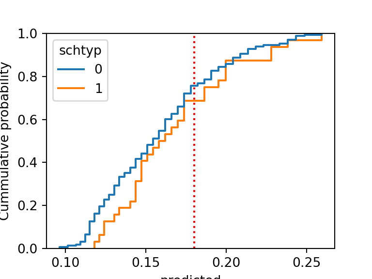

- Positive cases to the left of cuttoff are Type II errors
- Negative cases to the right of cutoff are Type I errors
- Probability curves nearly the same = poor model

# What is Deviance?

The significance of a GLM is expressed in terms of **deviance**

- Deviance can be challenging to understand what deviance really means
- Formally, deviance is the expected value of the ratio of one probability densitt function, $f_1(y)$ to a second probability density function, $f_2(y)$:

$$D\big[f_1(y),f_1(y) \Big] = 2 \int_y f_1(y) log \Bigg\{ \frac{f_1(y)}{f_2(y)} \Bigg\} dy$$

If $f_1(y) \rightarrow f_1(y)$, then:

$$log \Bigg\{
\frac{f_1(y)}{f_2(y)} \Bigg\} \rightarrow log(1) \rightarrow 0$$

And, $D\big[f_1(y),f_1(y) \Big] \rightarrow 0$

# What is Deviance?

Deviance is a measure of the divergence between two distributions

- Consider an easy to understand form of deviance for the Normal distribution
- Model with Normally distributed response
  - The mean squared error of a model is the deviance
  - If two distribution are identical the deviance is 0

# What is Deviance?

Deviance of a model can be evaluated using deviance with respect to a saturated model

$$\begin{align}
D(y,\hat{\mu}) &= 2 \Big( log \big( p(y | \hat{\theta}_{S}) \big) - log \big( p(y | \hat{\theta}_{0}) \big) \Big) \\
&= 2 \Big( \mathcal{l}(y | \hat{\theta}_{S}) - \mathcal{l}(y | \hat{\theta}_{0}) \Big)
\end{align}$$

# What is Deviance?

Fortunately, we can use the **deviance ratio** to compare models

$$D(y,\hat{\mu}) = Constant + 2 \mathcal{l}(y | \hat{\theta}_{0})$$

- Now the deviance ratio to compare two models, $M_1$ and $M_0$ is:

$$\begin{align}
D(\hat{\theta}_1,\hat{\theta}_0) &= \frac{Constant + 2 \mathcal{l}(y | \hat{\theta}_{0})}{Constant + 2 \mathcal{l}(y | \hat{\theta}_{1})} \\
&= Constant + 2 \mathcal{l}(y | \hat{\theta}_{0}) - Constant - 2 \mathcal{l}(y | \hat{\theta}_{1}) \\
&= 2 \mathcal{l}(y | \hat{\theta}_{0}) - 2 \mathcal{l}(y | \hat{\theta}_{1})
\end{align}$$

# What is Deviance?

Can compare with **null model** with **null deviance**

- Unfortunately, this quantity is usually just called, deviance, but is actually null deviance
- For large samples null deviance is Chi Squared distributed
- Test statistical significance of the model against the null model using the Chi Squared test
- Depends on Wilk’s theorem, and is referred to as **Wilk’s test**.
- Can comparing models with ratio of null deviance as well

# Summary

- Models with nonlinear response have non-Normal distributions
- The generalized linear model accomodates nonlinear response distributions
- Link function transforms to linear model
  - Inverse link function transforms from Normal distribution to response distribution
- Evaluating Binomial response models
  - Confusion matrix organizes
  - Compute metrics from elements of confsion matrix
  - Use multiple evaluation criteria
- Compare model performance with deviance